# RStudio Exercise 6: Analysis of longitudinal data

At the final week we analysed longitudinal data. We started with graphical displays and the summary method approach, and continued with linear mixed effects models for normal response variables.

Data Wrangling

The code for data wrangling can be found at my Github repository. The code without prints or graphs is implemented below to enable further analysis.

```r
library(dplyr)
```

```r
library(tidyr)
library(ggplot2)
library(GGally)
library(lme4)
BPRS <- read.table("https://raw.githubusercontent.com/KimmoVehkalahti/MABS/master/Examples/data/BPRS.txt",
                 sep=" ", header=TRUE)

rats <- read.table("https://raw.githubusercontent.com/KimmoVehkalahti/MABS/master/Examples/data/rats.txt",
                 sep="\t", header=TRUE)

# Factor treatment & subject
BPRS$treatment <- factor(BPRS$treatment)
BPRS$subject <- factor(BPRS$subject)

rats$ID <- factor(rats$ID)
rats$Group <- factor(rats$Group)

# Convert to long form
BPRSL <-  BPRS %>% gather(key = weeks, value = bprs, -treatment, -subject)
# Extract the week number
BPRSL <-  BPRSL %>% mutate(week = as.integer(substr(weeks, 5, 5)))


# Convert to long form
ratsl <-  rats %>% gather(key = WDs, value = weight, -ID, -Group)
# Extract the wd
ratsl <-  ratsl %>% mutate(WD = as.integer(substr(WDs, 3, 4)))
```

Part I: Graphical Displays and Summary Method Approach

The data included observations of 16 subjects (rats) that were divided into 3 groups. When analysing the data in the long form, we can analyse the individual response profiles by treatment group by building a ggplot that visualizes the responses of the individual subjects accross time. We can see that the rats in the Group 1 (n=8) have lower weights compared to Groups 2 (n=4) and 3 (n=4). The weights of the rats at Group 2 have the highest variance: one rat has significantly higher weight than the others.

```r
ratsl
```

```
##     ID Group  WDs weight WD
## 1    1     1  WD1    240  1
## 2    2     1  WD1    225  1
## 3    3     1  WD1    245  1
## 4    4     1  WD1    260  1
## 5    5     1  WD1    255  1
## 6    6     1  WD1    260  1
## 7    7     1  WD1    275  1
## 8    8     1  WD1    245  1
## 9    9     2  WD1    410  1
## 10  10     2  WD1    405  1
## 11  11     2  WD1    445  1
## 12  12     2  WD1    555  1
## 13  13     3  WD1    470  1
## 14  14     3  WD1    535  1
```

[output cut: 162 more lines]

```r
dim(rats)
```

```
## [1] 16 13
```

```r
summary(rats)
```

```
##        ID     Group      WD1             WD8             WD15
##  1      : 1   1:8   Min.   :225.0   Min.   :230.0   Min.   :230.0
##  2      : 1   2:4   1st Qu.:252.5   1st Qu.:255.0   1st Qu.:255.0
##  3      : 1   3:4   Median :340.0   Median :345.0   Median :347.5
##  4      : 1         Mean   :365.9   Mean   :369.1   Mean   :372.5
##  5      : 1         3rd Qu.:480.0   3rd Qu.:476.2   3rd Qu.:486.2
##  6      : 1         Max.   :555.0   Max.   :560.0   Max.   :565.0
##  (Other):10
##       WD22            WD29            WD36            WD43
##  Min.   :232.0   Min.   :240.0   Min.   :240.0   Min.   :243.0
##  1st Qu.:267.2   1st Qu.:268.8   1st Qu.:267.2   1st Qu.:269.2
##  Median :351.5   Median :356.5   Median :360.0   Median :360.0
##  Mean   :379.2   Mean   :383.9   Mean   :387.0   Mean   :386.0
##  3rd Qu.:492.5   3rd Qu.:497.8   3rd Qu.:504.2   3rd Qu.:501.0
##  Max.   :580.0   Max.   :590.0   Max.   :597.0   Max.   :595.0
##
##       WD44            WD50            WD57            WD64
##  Min.   :244.0   Min.   :238.0   Min.   :247.0   Min.   :245.0
##  1st Qu.:270.0   1st Qu.:273.8   1st Qu.:273.8   1st Qu.:278.0
##  Median :362.0   Median :370.0   Median :373.5   Median :378.0
##  Mean   :388.3   Mean   :394.6   Mean   :398.6   Mean   :404.1
##  3rd Qu.:510.5   3rd Qu.:516.0   3rd Qu.:524.5   3rd Qu.:530.8
##  Max.   :595.0   Max.   :612.0   Max.   :618.0   Max.   :628.0
##
```

```r
dim(ratsl)
```

```
## [1] 176   5
```

```r
names(ratsl)
```

```
## [1] "ID"     "Group"  "WDs"    "weight" "WD"
```

```r
str(ratsl)
```

```
## 'data.frame':    176 obs. of  5 variables:
##  $ ID    : Factor w/ 16 levels "1","2","3","4",..: 1 2 3 4 5 6 7 8 9 10 ...
##  $ Group : Factor w/ 3 levels "1","2","3": 1 1 1 1 1 1 1 1 2 2 ...
##  $ WDs   : chr  "WD1" "WD1" "WD1" "WD1" ...
##  $ weight: int  240 225 245 260 255 260 275 245 410 405 ...
##  $ WD    : int  1 1 1 1 1 1 1 1 1 1 ...
```

```r
summary(ratsl)
```

```
##        ID      Group      WDs                weight            WD
##  1      : 11   1:88   Length:176         Min.   :225.0   Min.   : 1.00
##  2      : 11   2:44   Class :character   1st Qu.:267.0   1st Qu.:15.00
##  3      : 11   3:44   Mode  :character   Median :344.5   Median :36.00
##  4      : 11                             Mean   :384.5   Mean   :33.55
##  5      : 11                             3rd Qu.:511.2   3rd Qu.:50.00
##  6      : 11                             Max.   :628.0   Max.   :64.00
##  (Other):110
```

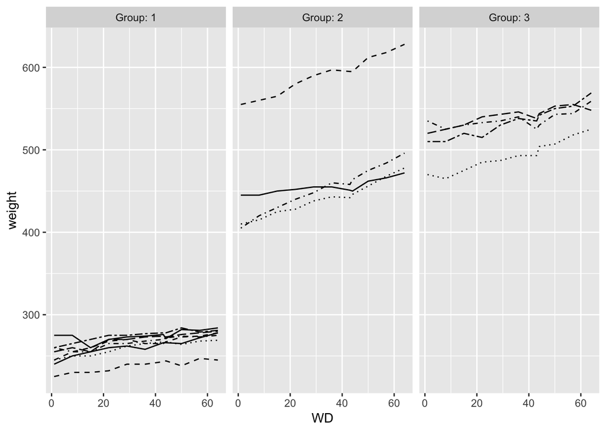

```r
ggplot(ratsl, aes(x = WD, y = weight, linetype = ID)) + geom_line() +
  scale_linetype_manual(values = rep(1:10, times = 4)) + facet_grid(.~Group, labeller = label_both) +
  theme(legend.position = "none") +
  scale_y_continuous(limits = c(min(ratsl$weight), max(ratsl$weight)))
```

We can take tracking into account when we standardize the data and plot the standardized responses. Standardization makes comparind individuals in the same groups and between groups more applicable. We can see from the plot below that the same individuals stand out as previously.

The individuals in Group 1 seem to gain weight quite steeply compared to at least Group 2. One individual whose weight dramatically drops in the beginning can be pointed out.

The individuals in Group 2 are not gaining weight as much compared to other groups. However, the growth is steadier.

The individuals in Group 3 are gaining weight more than Group 2 and more steadily than individuals in Group 1. All individuals in this group gain weight.

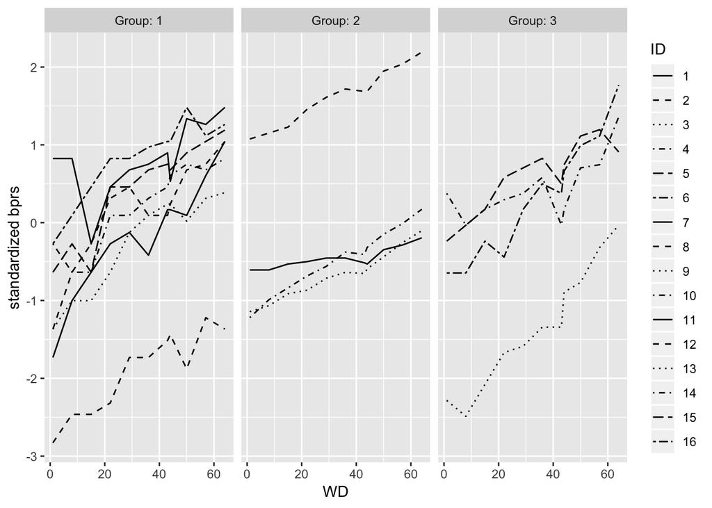

```r
# Standardized BPRS plots by groups
ratsl <- ratsl %>% group_by(Group) %>% mutate(weights_standardized = (weight - mean(weight))/sd(weight)) %>% ungroup()

ggplot(ratsl, aes(x = WD, y = weights_standardized, linetype = ID)) + geom_line() +
  scale_linetype_manual(values = rep(1:10, times = 4)) + facet_grid(. ~ Group, labeller = label_both) +
  scale_y_continuous(name = "standardized bprs")
```

Next we will analyse the average response profiles of each group of individuals. In the plot below, the standard error mean acts as an indicator of variance. We can see that the curves or their variances do not overlap. The mean starting weights of the groups were different, Groups 2 and 3 more closer to each other as mentioned before. As said before, Group 2 has the highest variance. Group 1 seems to have the smallest variance. The average weight of the individuals in a group grew the most in Group 2.

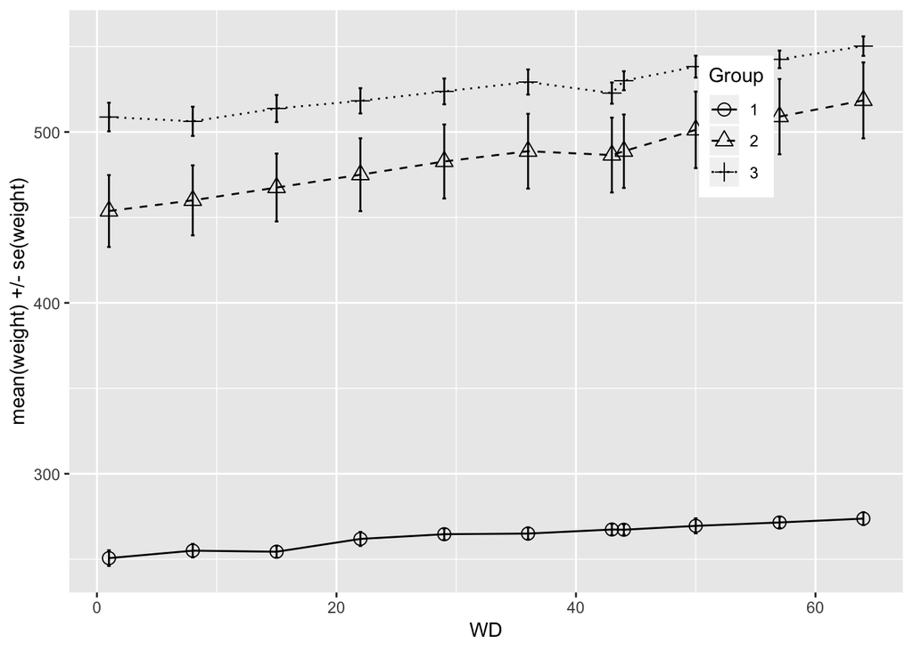

```r
# Summary measure analysis of longitudinal data
n <- ratsl$WD %>% unique() %>% length()
ratss <- ratsl %>% group_by(Group, WD) %>% summarise( mean = mean(weight), se = sd(weight)/sqrt(n)) %>% ungroup()

# glimpse(ratss)

# Plot the mean profiles
ggplot(ratss, aes(x = WD, y = mean, linetype = Group, shape = Group)) +
  geom_line() +
  scale_linetype_manual(values = c(1,2,3)) +
  geom_point(size=3) +
  scale_shape_manual(values = c(1,2,3)) +
  geom_errorbar(aes(ymin=mean-se, ymax=mean+se, linetype="1"), width=0.3) +
  theme(legend.position = c(0.8,0.8)) +
  scale_y_continuous(name = "mean(weight) +/- se(weight)")
```

We can also compare the avarage weights of the groups by boxplotting the data as below. The first-day respose/observation was removed from the data. We can see similar results from the boxplots as discussed above. However, now we can see more clearly that some outliers exist in each group.

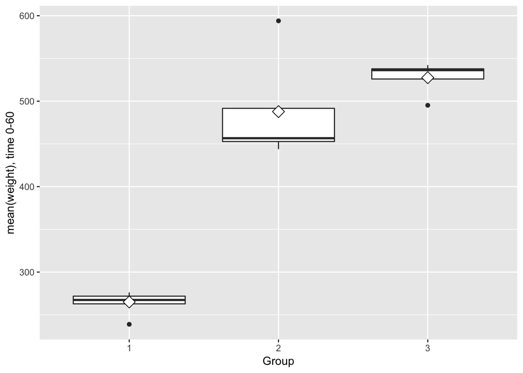

```r
# Create a summary data by treatment and subject with mean as the summary variable.
ratsl8s <- ratsl %>%
  filter(WD > 1) %>%
  group_by(Group, ID) %>%
  summarise( mean=mean(weight)) %>%
  ungroup()

# Glimpse the data
# glimpse(ratsl8s)

# Draw a boxplot of the mean versus group
ggplot(ratsl8s, aes(x = Group, y = mean)) +
  geom_boxplot() +
  stat_summary(fun.y = "mean", geom = "point", shape=23, size=4, fill = "white") +
  scale_y_continuous(name = "mean(weight), time 0-60")
```

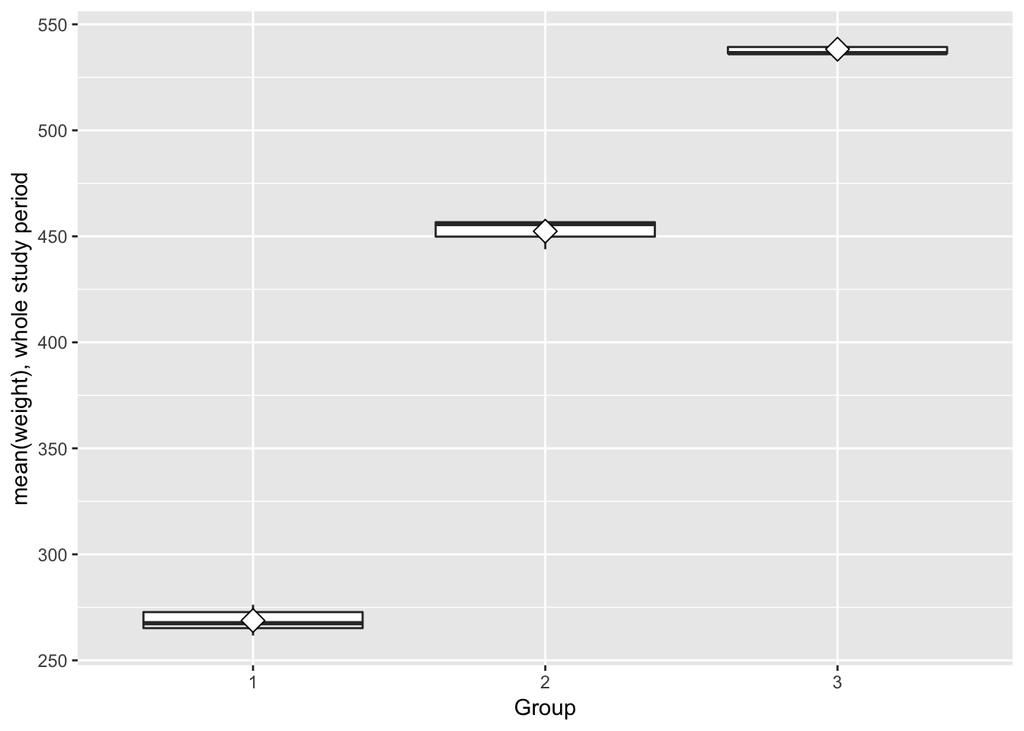

```r
# Filtering the outliers
ratsl8s_1 <- ratsl8s %>% filter(Group == 3)
ratsl8s_1 <- ratsl8s_1 %>% filter(mean > 500)
ratsl8s_2 <- ratsl8s %>% filter(Group !=3)
ratsl8s_2 <- ratsl8s_2 %>% filter(mean>250) %>% filter(mean < 500)
ratsl8s_filtered <- rbind(ratsl8s_2, ratsl8s_1)

ggplot(ratsl8s_filtered, aes(x = Group, y = mean)) +
  geom_boxplot() +
  stat_summary(fun.y = "mean", geom = "point", shape=23, size=4, fill = "white") +
  scale_y_continuous(name = "mean(weight), whole study period")
```

To analyse differences between the Groups in more detail, we perform a simple 2-sided t-test. We will perform the t-test with 3 different pairs of Groups because the test can handle only 2 groups at a time.

```r
ratsl8s12 <- ratsl8s %>% filter(Group != 3)
t.test(mean ~ Group, data = ratsl8s12, var.equal = TRUE)
```

```
##
##  Two Sample t-test
##
## data:  mean by Group
## t = -9.0646, df = 10, p-value = 3.88e-06
## alternative hypothesis: true difference in means is not equal to 0
## 95 percent confidence interval:
##  -277.5345 -168.0155
## sample estimates:
## mean in group 1 mean in group 2
##         265.025         487.800
```

```r
ratsl8s23 <- ratsl8s %>% filter(Group != 1)
t.test(mean ~ Group, data = ratsl8s23, var.equal = TRUE)
```

```
##
##  Two Sample t-test
##
## data:  mean by Group
## t = -1.0686, df = 6, p-value = 0.3263
## alternative hypothesis: true difference in means is not equal to 0
## 95 percent confidence interval:
##  -130.60428   51.20428
## sample estimates:
## mean in group 2 mean in group 3
##           487.8           527.5
```

```r
ratsl8s13 <- ratsl8s %>% filter(Group != 2)
t.test(mean ~ Group, data = ratsl8s13, var.equal = TRUE)
```

```
##
##  Two Sample t-test
##
## data:  mean by Group
## t = -27.824, df = 10, p-value = 8.345e-11
## alternative hypothesis: true difference in means is not equal to 0
## 95 percent confidence interval:
##  -283.4943 -241.4557
## sample estimates:
## mean in group 1 mean in group 3
##         265.025         527.500
```

Part II: Linear Mixed Effects Models for Normal Response Variables

Now we move our focus to the BPRS data. There are 40 individuals that have been randomized to a treatment Group 1 (n=20) and Treatment Group 2 (n=20). We observe the individuals’ change in the bprs value for 8 weeks.

```r
BPRS
```

```
##    treatment subject week0 week1 week2 week3 week4 week5 week6 week7 week8
## 1          1       1    42    36    36    43    41    40    38    47    51
## 2          1       2    58    68    61    55    43    34    28    28    28
## 3          1       3    54    55    41    38    43    28    29    25    24
## 4          1       4    55    77    49    54    56    50    47    42    46
## 5          1       5    72    75    72    65    50    39    32    38    32
## 6          1       6    48    43    41    38    36    29    33    27    25
## 7          1       7    71    61    47    30    27    40    30    31    31
## 8          1       8    30    36    38    38    31    26    26    25    24
## 9          1       9    41    43    39    35    28    22    20    23    21
## 10         1      10    57    51    51    55    53    43    43    39    32
## 11         1      11    30    34    34    41    36    36    38    36    36
## 12         1      12    55    52    49    54    48    43    37    36    31
## 13         1      13    36    32    36    31    25    25    21    19    22
## 14         1      14    38    35    36    34    25    27    25    26    26
```

[output cut: 26 more lines]

```r
dim(BPRS)
```

```
## [1] 40 11
```

```r
summary(BPRS)
```

```
##  treatment    subject       week0           week1           week2
##  1:20      1      : 2   Min.   :24.00   Min.   :23.00   Min.   :26.0
##  2:20      2      : 2   1st Qu.:38.00   1st Qu.:35.00   1st Qu.:32.0
##            3      : 2   Median :46.00   Median :41.00   Median :38.0
##            4      : 2   Mean   :48.00   Mean   :46.33   Mean   :41.7
##            5      : 2   3rd Qu.:58.25   3rd Qu.:54.25   3rd Qu.:49.0
##            6      : 2   Max.   :78.00   Max.   :95.00   Max.   :75.0
##            (Other):28
##      week3           week4           week5           week6
##  Min.   :24.00   Min.   :20.00   Min.   :20.00   Min.   :19.00
##  1st Qu.:29.75   1st Qu.:28.00   1st Qu.:26.00   1st Qu.:22.75
##  Median :36.50   Median :34.50   Median :30.50   Median :28.50
##  Mean   :39.15   Mean   :36.35   Mean   :32.55   Mean   :31.23
##  3rd Qu.:44.50   3rd Qu.:43.00   3rd Qu.:38.00   3rd Qu.:37.00
##  Max.   :76.00   Max.   :66.00   Max.   :64.00   Max.   :64.00
##
##      week7          week8
##  Min.   :18.0   Min.   :20.00
##  1st Qu.:23.0   1st Qu.:22.75
##  Median :30.0   Median :28.00
##  Mean   :32.2   Mean   :31.43
##  3rd Qu.:38.0   3rd Qu.:35.25
##  Max.   :62.0   Max.   :75.00
##
```

```r
dim(BPRSL)
```

```
## [1] 360   5
```

```r
names(BPRSL)
```

```
## [1] "treatment" "subject"   "weeks"     "bprs"      "week"
```

```r
str(BPRSL)
```

```
## 'data.frame':    360 obs. of  5 variables:
##  $ treatment: Factor w/ 2 levels "1","2": 1 1 1 1 1 1 1 1 1 1 ...
##  $ subject  : Factor w/ 20 levels "1","2","3","4",..: 1 2 3 4 5 6 7 8 9 10 ...
##  $ weeks    : chr  "week0" "week0" "week0" "week0" ...
##  $ bprs     : int  42 58 54 55 72 48 71 30 41 57 ...
##  $ week     : int  0 0 0 0 0 0 0 0 0 0 ...
```

```r
summary(BPRSL)
```

```
##  treatment    subject       weeks                bprs            week
##  1:180     1      : 18   Length:360         Min.   :18.00   Min.   :0
##  2:180     2      : 18   Class :character   1st Qu.:27.00   1st Qu.:2
##            3      : 18   Mode  :character   Median :35.00   Median :4
##            4      : 18                      Mean   :37.66   Mean   :4
##            5      : 18                      3rd Qu.:43.00   3rd Qu.:6
##            6      : 18                      Max.   :95.00   Max.   :8
##            (Other):252
```

```r
glimpse(BPRSL)
```

```
## Observations: 360
## Variables: 5
## $ treatment <fct> 1, 1, 1, 1, 1, 1, 1, 1, 1, 1, 1, 1, 1, 1, 1, 1, 1, 1...
## $ subject   <fct> 1, 2, 3, 4, 5, 6, 7, 8, 9, 10, 11, 12, 13, 14, 15, 1...
## $ weeks     <chr> "week0", "week0", "week0", "week0", "week0", "week0"...
## $ bprs      <int> 42, 58, 54, 55, 72, 48, 71, 30, 41, 57, 30, 55, 36, ...
## $ week      <int> 0, 0, 0, 0, 0, 0, 0, 0, 0, 0, 0, 0, 0, 0, 0, 0, 0, 0...
```

We first take a look at the data by plotting the bprs values against weeks for the data. We do not draw the lines but identify the group to which each observation belongs. We can see that the individuals who point out with the highest values belong to the Group 2 almost each week. Otherwise we can see that the responses overlap strongly. We can assume a pattern where the bprs values decrease accross time for both groups. It also seems that there is a small increase of the bprs values during the last week but we cannot yet say if there has been that kind of an inrease or not.

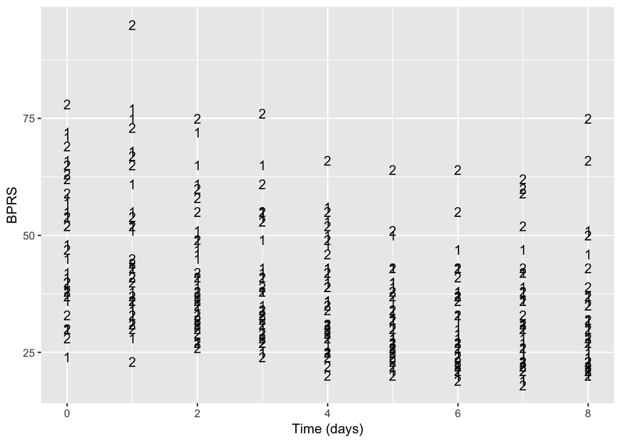

```r
ggplot(BPRSL, aes(x = week, y = bprs)) + geom_text(aes(label = treatment)) + scale_x_continuous(name = "Time (days)") + scale_y_continuous(name = "BPRS") + theme(legend.position = "top")
```

When analysing the individual response profiles by treatment group, we do not see anything relevant from the data. The groups to not seem very different, except the same observation that could be seen in the previous plot (the individuals who point out with the highest values belong to the Group 2 almost each week).

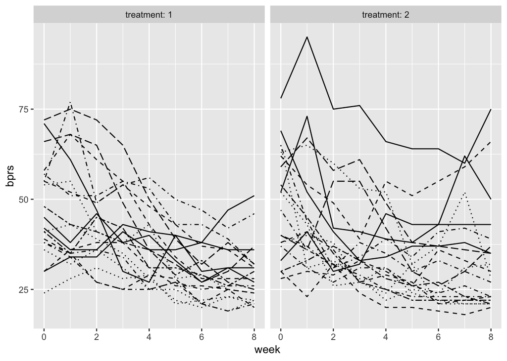

```r
ggplot(BPRSL, aes(x = week, y = bprs, linetype = subject)) +
  geom_line() +
  scale_linetype_manual(values = rep(1:10, times=4)) +
  facet_grid(. ~ treatment, labeller = label_both) +
  theme(legend.position = "none") +
  scale_y_continuous(limits = c(min(BPRSL$bprs), max(BPRSL$bprs)))
```

Now we analyse the differences of the groups by building a linear regression model. I build a model with week, treatment, and week*treatment as explaining variables. Only week turned out statistically significant. According to these results, we can hypothesise that the effect of treatments did not differ from each other.

```r
# building a linear regression model
BPRS_model <- lm(data = BPRSL, bprs ~ week + treatment + week*treatment)
summary(BPRS_model)
```

```
##
## Call:
## lm(formula = bprs ~ week + treatment + week * treatment, data = BPRSL)
##
## Residuals:
##     Min      1Q  Median      3Q     Max
## -23.886  -9.267  -2.801   6.513  51.318
##
## Coefficients:
##                 Estimate Std. Error t value Pr(>|t|)
## (Intercept)      47.8856     1.6970  28.218  < 2e-16 ***
## week             -2.6283     0.3564  -7.374 1.17e-12 ***
## treatment2       -2.2911     2.3999  -0.955    0.340
## week:treatment2   0.7158     0.5041   1.420    0.156
## ---
## Signif. codes:  0 '***' 0.001 '**' 0.01 '*' 0.05 '.' 0.1 ' ' 1
##
## Residual standard error: 12.35 on 356 degrees of freedom
## Multiple R-squared:  0.1897, Adjusted R-squared:  0.1829
## F-statistic: 27.78 on 3 and 356 DF,  p-value: 3.629e-16
```

Now we will take a look at a more appropriate model for this kind of data, the Random Intercept Model. In the model we first use week and treatment as fixed-effect terms and (1 | subject) as a term implicating random-effect.

```r
BPRS_ref <- lmer(bprs ~ week + treatment + (1 | subject), data = BPRSL, REML = FALSE)
summary(BPRS_ref)
```

```
## Linear mixed model fit by maximum likelihood  ['lmerMod']
## Formula: bprs ~ week + treatment + (1 | subject)
##    Data: BPRSL
##
##      AIC      BIC   logLik deviance df.resid
##   2748.7   2768.1  -1369.4   2738.7      355
##
## Scaled residuals:
##     Min      1Q  Median      3Q     Max
## -3.0481 -0.6749 -0.1361  0.4813  3.4855
##
## Random effects:
##  Groups   Name        Variance Std.Dev.
##  subject  (Intercept)  47.41    6.885
##  Residual             104.21   10.208
## Number of obs: 360, groups:  subject, 20
##
## Fixed effects:
##             Estimate Std. Error t value
## (Intercept)  46.4539     1.9090  24.334
## week         -2.2704     0.2084 -10.896
## treatment2    0.5722     1.0761   0.532
##
## Correlation of Fixed Effects:
##            (Intr) week
## week       -0.437
## treatment2 -0.282  0.000
```

Next we use week and treatment as fixed-effect terms and (week | subject) as the random-effect term.

```r
BPRS_ref1 <- lmer(bprs ~ week + treatment + (week | subject), data = BPRSL, REML = FALSE)
summary(BPRS_ref1)
```

```
## Linear mixed model fit by maximum likelihood  ['lmerMod']
## Formula: bprs ~ week + treatment + (week | subject)
##    Data: BPRSL
##
##      AIC      BIC   logLik deviance df.resid
##   2745.4   2772.6  -1365.7   2731.4      353
##
## Scaled residuals:
##     Min      1Q  Median      3Q     Max
## -2.8919 -0.6194 -0.0691  0.5531  3.7976
##
## Random effects:
##  Groups   Name        Variance Std.Dev. Corr
##  subject  (Intercept) 64.8202  8.0511
##           week         0.9608  0.9802   -0.51
##  Residual             97.4307  9.8707
## Number of obs: 360, groups:  subject, 20
##
## Fixed effects:
##             Estimate Std. Error t value
## (Intercept)  46.4539     2.1052  22.066
## week         -2.2704     0.2977  -7.626
## treatment2    0.5722     1.0405   0.550
##
## Correlation of Fixed Effects:
##            (Intr) week
## week       -0.582
## treatment2 -0.247  0.000
```

When performing ANOVA between the two models, we can see from the results (chi-squared and p-value) that the random intercept and random slope model performs better and has a higher significance with lower values.

```r
anova(BPRS_ref1, BPRS_ref)
```

```
## Data: BPRSL
## Models:
## BPRS_ref: bprs ~ week + treatment + (1 | subject)
## BPRS_ref1: bprs ~ week + treatment + (week | subject)
##           Df    AIC    BIC  logLik deviance  Chisq Chi Df Pr(>Chisq)
## BPRS_ref   5 2748.7 2768.1 -1369.4   2738.7
## BPRS_ref1  7 2745.4 2772.6 -1365.7   2731.4 7.2721      2    0.02636 *
## ---
## Signif. codes:  0 '***' 0.001 '**' 0.01 '*' 0.05 '.' 0.1 ' ' 1
```